# Kaggle Competition: Zillow’s House Value Prediction

YX.Wang

In this simple starter,I’ll show standard steps of how I deal with the competition.The goal of the competition is to predict the estimation owned by Zillow company itself (called **Zestimate**).

Outline:

- First,we’ll show a quick EDA in order to dig implicit information of the data.
- As to handling a piece of data with so many missing values and some meaningless colunms,data preprocessing is quite important.
- Feature engineering will be our third part.
- In the training section,two popular packages will be contained,including the well-known **xgboost** and **Lightgbm**.

### Package loading and data importing

```r
  library(knitr)
  library(tidyverse)
  library(data.table)
  library(DT)
  library(ggplot2)
  library(corrplot)
  library(geosphere)
  library(magrittr)
  library(dplyr)
  library(caret)
  library(Matrix)
  library(xgboost)
  library(lightgbm)
```

```r
setwd("C:/Users/YMM/Desktop/house")

data_pro <- fread("properties_2016.csv",sep=",",header=T,na.strings="",showProgress=FALSE,verbose=FALSE)
data_V2 <- fread("train_2016_v2.csv",sep=",",header=T,na.strings="",showProgress=FALSE,verbose=FALSE)
```

### Take a glimpse

Before diving into the preprocessing part,let’s take a quick look of the data

```r
datatable(head(data_pro,100), style="bootstrap", class="table-condensed", options = list(dom = 'tp',scrollX = TRUE))
```

|  | parcelid | airconditioningtypeid | architecturalstyletypeid | basementsqft | bathroomcnt | bedroomcnt | buildingclasstypeid | buildingqualitytypeid | calculatedbathnbr | decktypeid | finishedfloor1squarefeet | calculatedfinishedsquarefeet | finishedsquarefeet12 | finishedsquarefeet13 | finishedsquarefeet15 | finishedsquarefeet50 | finishedsquarefeet6 | fips | fireplacecnt | fullbathcnt | garagecarcnt | garagetotalsqft | hashottuborspa | heatingorsystemtypeid | latitude | longitude | lotsizesquarefeet | poolcnt | poolsizesum | … |
| --- | --- | --- | --- | --- | --- | --- | --- | --- | --- | --- | --- | --- | --- | --- | --- | --- | --- | --- | --- | --- | --- | --- | --- | --- | --- | --- | --- | --- | --- | --- |
| 1 | 10754147 |  |  |  | 0 | 0 |  |  |  |  |  |  |  |  |  |  |  | 6037 |  |  |  |  |  |  | 34144442 | -118654084 | 85768 |  |  | … |
| 2 | 10759547 |  |  |  | 0 | 0 |  |  |  |  |  |  |  |  |  |  |  | 6037 |  |  |  |  |  |  | 34140430 | -118625364 | 4083 |  |  | … |
| 3 | 10843547 |  |  |  | 0 | 0 |  |  |  |  |  | 73026 |  |  | 73026 |  |  | 6037 |  |  |  |  |  |  | 33989359 | -118394633 | 63085 |  |  | … |
| 4 | 10859147 |  |  |  | 0 | 0 | 3 | 7 |  |  |  | 5068 |  |  | 5068 |  |  | 6037 |  |  |  |  |  |  | 34148863 | -118437206 | 7521 |  |  | … |
| 5 | 10879947 |  |  |  | 0 | 0 | 4 |  |  |  |  | 1776 |  |  | 1776 |  |  | 6037 |  |  |  |  |  |  | 34194168 | -118385816 | 8512 |  |  | … |
| 6 | 10898347 |  |  |  | 0 | 0 | 4 | 7 |  |  |  | 2400 |  |  | 2400 |  |  | 6037 |  |  |  |  |  |  | 34171873 | -118380906 | 2500 |  |  | … |
| 7 | 10933547 |  |  |  | 0 | 0 |  |  |  |  |  |  |  |  |  |  |  | 6037 |  |  |  |  |  |  | 34131929 | -118351474 |  |  |  | … |
| 8 | 10940747 |  |  |  | 0 | 0 |  |  |  |  |  | 3611 |  |  | 3611 |  |  | 6037 |  |  |  |  |  |  | 34171345 | -118314900 | 5333 |  |  | … |
| 9 | 10954547 |  |  |  | 0 | 0 |  |  |  |  |  |  |  |  |  |  |  | 6037 |  |  |  |  |  |  | 34218210 | -118331311 | 145865 |  |  | … |
| 10 | 10976347 |  |  |  | 0 | 0 | 3 | 7 |  |  |  | 3754 |  |  | 3754 |  |  | 6037 |  |  |  |  |  |  | 34289776 | -118432085 | 7494 |  |  | … |

[output cut: 90 more lines]

Obviously,many colnums have missing values while most of conventional models (e.g. random forests, SVM, GLM..etc)don’t accept NAs in data.However,both of **xgboost** and **Lightgbm** can tackle with this issue by default.

Visulization will be a useful and intuitive tool to get the sense of messy data!

In the next few sections,I’ll display some figures depicting structure of the data.

#### Proportions of missing values

As we’ve mentioned earlier,incomplete data is a severe issue in this case.The figure below is the percentage of missing values by features.

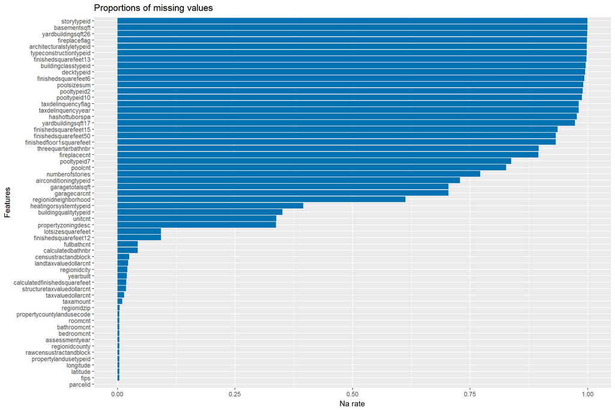

```r
na_rate <-
  data_pro %>%
  sapply(.,function(x) sum(is.na(x))/nrow(.)) %>%
  as.data.frame() %>%
  rownames_to_column(.,var="feature")

colnames(na_rate) <- c("feature","na.rate")

na_rate%>%
  ggplot(aes(x=reorder(feature,na.rate),y=na.rate))+geom_bar(stat="identity",fill="#0072B2")+labs(x ="Features",y ="Na rate",title="Proportions of missing values")+coord_flip()+theme_gray()
```

#### Distribution of target

Our target in the model is *logerror* and the plot below is how *logerror*’s density function looks like.

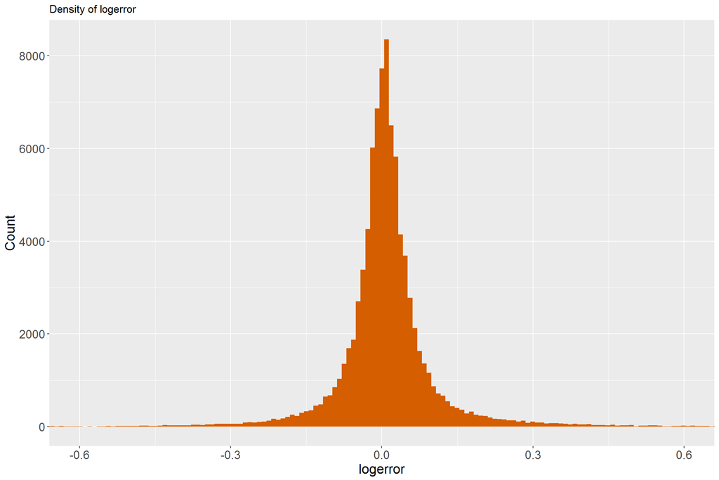

```r
data_V2 %>% ggplot(aes(x=logerror)) + geom_histogram(bins=1000, fill="#D55E00")+theme_gray()+theme(axis.title=element_text(size=16),axis.text = element_text(size=14))+ylab("Count")+coord_cartesian(x=c(-0.6,0.6))+labs(title="Density of logerror")
```

As we can see,there are still few outliers far from the main body of bell-shaped hill.We’ll consider to remove some outliers later in order to improve accuracy of our model.

### Correlation of variables

If the correlation between two variables are too high (either positive or negative),then we might consider them as the duplicate columns in the sense of information content.

Before drawing correlation plot.We need to define the class of each column.Since it’s difficult to determine the class automatically due to the inconsistency of variables’ format,manually checking is prefered in this case.

```r
m.n.l_var_index <- which(names(data_pro) %in%
                             c("finishedsquarefeet6",
                             "finishedsquarefeet12",
                             "finishedsquarefeet13",
                             "finishedsquarefeet15",
                             "finishedsquarefeet50",
                             "assessmentyear"))

data_pro <- data_pro[,-m.n.l_var_index,with=FALSE]
#index of categorical variables
cat_index <- which(names(data_pro) %in%
                     c("parcelid",
                       "airconditioningtypeid",
                       "architecturalstyletypeid",
                       "buildingclasstypeid",
                       "buildingqualitytypeid",
                       "decktypeid",
                       "fips",
                       "hashottuborspa",
                       "rawcensustractandblock",
                       "heatingorsystemtypeid",
                       "latitude",
                       "longitude",
                       "poolcnt",
                       "pooltypeid10",
                       "pooltypeid2",
                       "pooltypeid7",
                       "propertycountylandusecode",
                       "propertylandusetypeid",
                       "propertyzoningdesc",
                       "regionidcity",
                       "regionidcounty",
                       "regionidneighborhood",
                       "regionidzip",
                       "storytypeid",
                       "typeconstructiontypeid",
                       "unitcnt",
                       "yearbuilt",
                       "fireplaceflag",
                       "taxdelinquencyflag",
                       "censustractandblock",
                       "transactiondate"
                     ))

#index of numerical variables
num_index <- which(names(data_pro) %in%
                     c("calculatedbathnbr",
                       "basementsqft",
                       "bathroomcnt",
                       "bedroomcnt",
                       "finishedfloor1squarefeet",
                       "calculatedfinishedsquarefeet",
                       "fireplacecnt",
                       "fullbathcnt",
                       "garagecarcnt",
                       "garagetotalsqft",
                       "lotsizesquarefeet",
                       "poolsizesum",
                       "threequarterbathnbr",
                       "yardbuildingsqft17",
                       "yardbuildingsqft26",
                       "numberofstories",
                       "structuretaxvaluedollarcnt",
                       "taxvaluedollarcnt",
                       "landtaxvaluedollarcnt",
                       "taxamount",
                       "taxdelinquencyyear",
                       "logerror"
                     ))
```

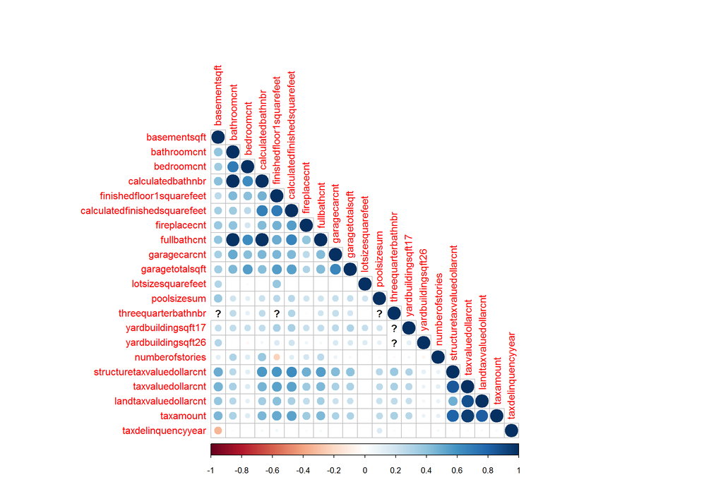

```r
num_var <-data_pro[,num_index,with=FALSE]
M<-cor(num_var,use="pairwise.complete.obs")
corrplot(M, type="lower")
```

Focus on the dark colored circles,we can find three pairs of highly-correlated features roughly:

1.*calculatedbathnbr* against *bathroomcnt*

```r
cat("Correlation coefficient of calculatedbathnbr and bathroomcnt is",M[4,2])
```

```
## Correlation coefficient of calculatedbathnbr and bathroomcnt is 1
```

Two colums are exactly the same!Dropping *calculatedbathnbr* later.

2.*fullbathcnt* against *bathroomcnt*

```r
cat("Correlation coefficient of fullbathcnt and bathroomcnt is",M[8,2])
```

```
## Correlation coefficient of fullbathcnt and bathroomcnt is 0.9873602
```

Two variables are almost the same,but the difference between these two is the definition of full bathroom.A so called *0.5 bathroom* does not include a “bath tub” nor “shower”, only the toilet.We think there are still some slightly distinctive information contained between these two features.A more theorically-based reason we do not drop either of one is because we don’t cover any linear models in this starter so the collinearity won’t be an issue.

3.*taxamount* against *taxvaluedollarcnt*

```r
cat("Correlation coefficient of taxamount and taxvaluedollarcnt is",M[20,18])
```

```
## Correlation coefficient of taxamount and taxvaluedollarcnt is 0.9497309
```

A pair of high correlation variables with slightly different meaning. The definitions of *parcel* and *property* are not very clear to me but seems like the former only contain the land while the later cover the buildings on the land.For the sake of feature diversity and,again,the absence of harm caused by collinearity,we’ll keep them as our predictors.

### Feature engineering

Base on the conclusion above,we’ll drop *calculatedbathnbr* and move on to some analysis between categorical features and target.

```r
data_pro <- data_pro %>%
  select(-calculatedbathnbr)

data_for_train <- merge(data_pro,data_V2,by="parcelid",all.y=TRUE)

datatable(head(data_for_train,100), style="bootstrap", class="table-condensed", options = list(dom = 'tp',scrollX = TRUE))
```

|  | parcelid | airconditioningtypeid | architecturalstyletypeid | basementsqft | bathroomcnt | bedroomcnt | buildingclasstypeid | buildingqualitytypeid | decktypeid | finishedfloor1squarefeet | calculatedfinishedsquarefeet | fips | fireplacecnt | fullbathcnt | garagecarcnt | garagetotalsqft | hashottuborspa | heatingorsystemtypeid | latitude | longitude | lotsizesquarefeet | poolcnt | poolsizesum | pooltypeid10 | pooltypeid2 | pooltypeid7 | propertycountylandusecode | propertylandusetypeid | propertyzoningdesc | … |
| --- | --- | --- | --- | --- | --- | --- | --- | --- | --- | --- | --- | --- | --- | --- | --- | --- | --- | --- | --- | --- | --- | --- | --- | --- | --- | --- | --- | --- | --- | --- |
| 1 | 10711738 | 1 |  |  | 3 | 4 |  | 4 |  |  | 2538 | 6037 |  | 3 |  |  |  | 2 | 34220381 | -118620802 | 11012 | True |  |  |  | True | 0101 | 261 | LARE11 | … |
| 2 | 10711755 | 1 |  |  | 3 | 3 |  | 4 |  |  | 1589 | 6037 |  | 3 |  |  |  | 2 | 34222040 | -118622240 | 11010 | True |  |  |  | True | 0101 | 261 | LARE11 | … |
| 3 | 10711805 | 1 |  |  | 2 | 3 |  | 4 |  |  | 2411 | 6037 |  | 2 |  |  |  | 2 | 34220427 | -118618549 | 11723 | True |  |  |  | True | 0101 | 261 | LARE9 | … |
| 4 | 10711816 | 1 |  |  | 2 | 4 |  | 4 |  |  | 2232 | 6037 |  | 2 |  |  |  | 2 | 34222390 | -118618631 | 9002 |  |  |  |  |  | 0100 | 261 | LARE9 | … |
| 5 | 10711858 | 1 |  |  | 2 | 4 |  | 4 |  |  | 1882 | 6037 |  | 2 |  |  |  | 2 | 34222544 | -118617961 | 9002 | True |  |  |  | True | 0101 | 261 | LARE9 | … |
| 6 | 10711910 |  |  |  | 2 | 3 |  | 4 |  |  | 1477 | 6037 |  | 2 |  |  |  | 2 | 34221864 | -118615739 | 11285 | True |  |  |  | True | 0101 | 261 | LARE11 | … |
| 7 | 10712086 | 1 |  |  | 2 | 4 |  | 4 |  |  | 1850 | 6037 |  | 2 |  |  |  | 2 | 34226039 | -118618527 | 9089 | True |  |  |  | True | 0101 | 261 | LARE9 | … |
| 8 | 10712162 | 1 |  |  | 3 | 3 |  | 4 |  |  | 3193 | 6037 |  | 3 |  |  |  | 2 | 34226833 | -118612917 | 15577 | True |  |  |  | True | 0101 | 261 | LARE11 | … |
| 9 | 10712163 | 1 |  |  | 3 | 4 |  | 4 |  |  | 2421 | 6037 |  | 3 |  |  |  | 2 | 34226843 | -118612422 | 10584 | True |  |  |  | True | 0101 | 261 | LARE11 | … |
| 10 | 10712195 | 1 |  |  | 3 | 3 |  | 4 |  |  | 1678 | 6037 |  | 3 |  |  |  | 2 | 34223689 | -118612746 | 14948 |  |  |  |  |  | 0100 | 261 | LARE11 | … |

[output cut: 90 more lines]

```r
dim(data_for_train)
```

```
## [1] 90275    53
```

After merging the raw data with transaction data,we obtain much fewer observations.

Now,basic imputation will be conducted if we believe Na means the contrast side in few binary features (e.g. Na in *poolcnt* and Na in *hashottuborspa* may both means “None”.)

```r
which(sapply(data_for_train,n_distinct)==2)
```

```
## buildingclasstypeid          decktypeid      hashottuborspa
##                   7                   9                  17
##             poolcnt        pooltypeid10         pooltypeid2
##                  22                  24                  25
##         pooltypeid7         storytypeid       fireplaceflag
##                  26                  36                  44
##  taxdelinquencyflag
##                  49
```

```r
data_for_train$hashottuborspa <- ifelse(is.na(data_for_train$hashottuborspa),
                                        "false",data_for_train$hashottuborspa)

data_for_train$poolcnt <- ifelse(is.na(data_for_train$poolcnt),
                                        "no","yes")

data_for_train$pooltypeid10 <- ifelse(is.na(data_for_train$pooltypeid10),
                                         "no","yes")

data_for_train$pooltypeid2 <- ifelse(is.na(data_for_train$pooltypeid2),
                                         "no","yes")

data_for_train$pooltypeid7 <- ifelse(is.na(data_for_train$pooltypeid7),
                                         "no","yes")

data_for_train$fireplaceflag <- ifelse(is.na(data_for_train$fireplaceflag),
                                        "false",data_for_train$fireplaceflag)

data_for_train$taxdelinquencyflag <- ifelse(is.na(data_for_train$taxdelinquencyflag),                                      "N",data_for_train$taxdelinquencyflag)
```

#### Drop featres with more than 60% of missing values

After the reasonable imputation above,a nature view to treat features with too many missing values is that they are probably redundent or even wrongly recorded.Such variables are more like *noise* instead of *information* which may deteriorate performance of the model.

```r
na_rate_train <- data_for_train %>%
  sapply(.,function(x) sum(is.na(x))/nrow(.))

data_for_train <- data_for_train[,which(na_rate_train<=0.6),with=FALSE]
```

We ’ll show some intuitive figures for the purpose of observing relationship between target and some features.

### *Years of buildings* and *logerror*

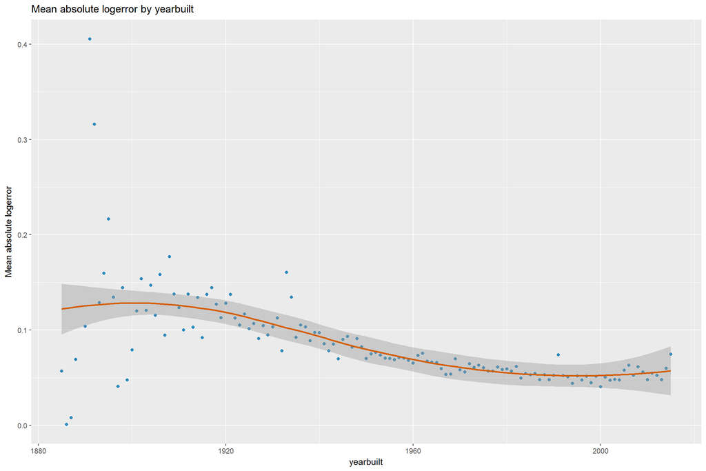

```r
data_for_train[, list(mean_abs_error=mean(abs(logerror))), by=yearbuilt] %>%
    ggplot(aes(x=yearbuilt, y=mean_abs_error)) +
    geom_point(color="#0072B2", alpha=0.8) +
    geom_smooth(color="#D55E00") +
    labs(y='Mean absolute logerror', title='Mean absolute logerror by yearbuilt')
```

In general,the trend declines as the *year built* get closer to now.This is an interesting fact implying that Zillow might be more accurate in estimating new houses than old ones.

Adding a feature named *ages* to represent the degree of depreciation of houses.

```r
data_for_train$ages <- 2017-data_for_train$yearbuilt
```

### *Distance from the center of houses* and *logerror*

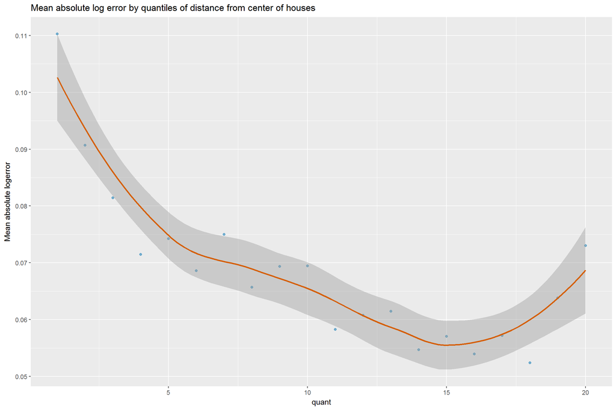

```r
data_for_train$long <- data_for_train$longitude/1e6
data_for_train$lat <- data_for_train$latitude/1e6
data_for_train$longmean <- mean((data_for_train$long), na.rm=TRUE)
data_for_train$latmean <- mean((data_for_train$lat), na.rm=TRUE)

data_for_train$geodist <- distHaversine(data_for_train[,c("long","lat"),with=FALSE],
                    data_for_train[,c("longmean","latmean"),with=FALSE])

data_for_train$quant <- ntile(data_for_train$geodist, 20)

data_for_train[, list(mean_error=mean(abs(logerror))),by=quant] %>%
    ggplot(aes(x=quant, y=mean_error)) +
    geom_point(color="#0072B2", alpha=0.5) +
    geom_smooth(color="#D55E00") +
    labs(y='Mean absolute logerror', title='Mean absolute log error by quantiles of distance from center of houses')
```

Of what fact I aware is that the group of houses closest to the center is the most mis-estimated one.This phenomena is contrast with our common conjecture. Maybe it’s a good idea to mutate a new feature representing geomatric distance from center.

### Xgboost training

Two notes need to mentention about **xgboost**:

-Since xgboost can handle NA in data with so called *Sparsity-aware Split Finding* strategy,we do not need to impute missing values.

-One-hot-encoding is required in *xgboost*.We’ll perform a throughly arrange before training.

```r
data_for_train <- data_for_train %>%
  select(-latitude,-longitude,-yearbuilt,-long,-lat,-longmean,-latmean,-quant)

cat_index_train <- which(names(data_for_train) %in%
                      c("parcelid",
                       "airconditioningtypeid",
                       "architecturalstyletypeid",
                       "buildingclasstypeid",
                       "buildingqualitytypeid",
                       "decktypeid",
                       "fips",
                       "hashottuborspa",
                       "rawcensustractandblock",
                       "heatingorsystemtypeid",
                       "poolcnt",
                       "pooltypeid10",
                       "pooltypeid2",
                       "pooltypeid7",
                       "propertycountylandusecode",
                       "propertylandusetypeid",
                       "propertyzoningdesc",
                       "regionidcity",
                       "regionidcounty",
                       "regionidneighborhood",
                       "regionidzip",
                       "storytypeid",
                       "typeconstructiontypeid",
                       "unitcnt",
                       "fireplaceflag",
                       "taxdelinquencyflag",
                       "censustractandblock",
                       "transactiondate"
                     ))

data_for_train <- as.data.frame(data_for_train )

data_for_train[,cat_index_train] %<>%
  lapply(function(x) as.factor(x))

data_for_train[,-cat_index_train] %<>%
  lapply(function(x) as.numeric(x))
```

Just one step before training,we adopt `sparse.model.matrix` in package **Matrix** instead of other one-hot-encoder (e.g. common counterpart `dummyvars` in package **caret**) due to the RAM limit.

Furthermore,we try to drop some outliers with large absolute logerror.

```r
previous_na_action <- options('na.action')
options(na.action='na.pass')

data_sparse_train <- sparse.model.matrix(logerror~.-1,data=data_for_train %>% select(-parcelid,-transactiondate)%>% filter(logerror>-0.5,logerror<0.5),verbose=FALSE)

options(na.action=previous_na_action$na.action)

param <- list(
  booster = "gbtree",
  objective="reg:linear",
  eval_metric = "mae",
  eta = .05,
  max_depth = 2,
  min_child_weight = 4,
  subsample = 0.6,
  colsample_bytree=0.4,
  gamma=0,
  lambda=10
)

xgb_cv <- xgb.cv(data=data_sparse_train,
                 label=as.matrix(data_for_train%>%filter(logerror<0.5,logerror>-0.5) %>% select(logerror)),
                 params=param,
                 nrounds=500,
                 prediction=TRUE,
                 verbose=0,
                 nfold=10,
                 early_stopping_rounds=50
                 )

xgb_cv$evaluation_log$test_mae_mean[xgb_cv$best_iteration]
```

```
## [1] 0.0550014
```

### Lightgbm training

*Lightgbm* is also a tree-based algorithm,like *xgboost*,with different strategy when deciding splits.Though,there are some settings in both packages that can make them very similar to another.

One of the main features of *Lightgbm* is it allows you to define the index of categorical predictors directly,instead of having to spend time performing one-hot-encoding.

```r
x <- data_for_train %>%
  filter(logerror>-0.5,logerror<0.5)%>%
  select(-logerror,-parcelid,transactiondate)

y <- data_for_train %>%
  filter(logerror>-0.5,logerror<0.5)

gb_train = lgb.Dataset(data.matrix(x),
                       label=y$logerror,
                       categorical_feature = which(sapply(x,class)=="factor"))


params.lgb = list(
  objective = "regression_l1"
  , metric = "mae"
  , min_data_in_leaf = 1
  , feature_fraction = 0.6
  , bagging_fraction = 0.6
  , num_leaves = 400
  , max_depth = 2
  , lambda_l2 = 50
)

lgb_cv <- lgb.cv(
  params = params.lgb
  , data = gb_train
  , nfold=10
  , learning_rate = 0.01
  , nrounds = 500
  , early_stopping_rounds = 300
  , verbose = 0
  , stratified = FALSE
)

min(unlist(lgb_cv$record_evals$valid$l1$eval))
```

```
## [1] 0.05509142
```

### What’s more & What’s next?

In this starter,we perform standard steps on conducting models to make a estimation of *Zestimate*.Actually,it’s not complete since we omit the hyperparameter-tuning sections here in order to save some time.When performing hyperparameter-tuning,grid search and a novel alternative named *Baysian Optimization* are both in my toolkit.But they are very time-consuming while not making a certain extent of improvement.That’s why you the reader may think some settings in this starter arbitrary.

The biggest differences between machine learning algorithms and common tools we use frequently in the area of social science (e.g. we use variety of regression models in econometrics) to me,is the former doesn’t require all your features or settings are meaningful or sensible.For example,we don’t need to specify the reason of picking 0.5 and -0.5 as the split points of outliers,it’s all result-driven!

What we can do to obtain better accuracy,is the better realization about information in data and it requires deeper domain knowledge.Maybe we’ll try to implement more comprehensive feature engineering soon.